# SP Test

Part 2

Alejandro Jiménez Rico

## Step 1

**Please calculate the 2nd day, 7th day and 10th day retention (which is the percentage of people that downloaded the game on day 1 who played again on day 2, 7 and 10). Please calculate the retention in two ways, using the user id (user_id) and then the device id (client_mobile_device_aid). (Please note that you only have the device id from the 14th of April).**

```r
library(data.table)
library(tidyverse)
library(lubridate)
library(viridis)
percent <- function(x, digits = 2, format = "f", ...) {
  paste0(formatC(100 * x, format = format, digits = digits, ...), "%")
}
raw.user <- fread('data/sh_user.csv')
raw.session <- fread('data/sh_session.csv')
raw.battles <- fread('data/sh_battles.csv')
```

```r
glimpse(raw.user)
```

```
Observations: 17,988
Variables: 54
$ V1                                      <chr> "1", "2", "3", "4", "5", "6", "7", "8", "9", "10", "11", "12"...
$ user_id                                 <dbl> 3.042986e+18, 1.234560e+05, 3.043158e+18, 3.043160e+18, 3.043...
$ last_session_id                         <dbl> 3.042986e+18, 1.234560e+05, 3.043158e+18, 3.043160e+18, 3.043...
$ date_register                           <chr> "2014-11-26", "2014-11-26", "2014-11-27", "2014-11-27", "2014...
$ date_register_android                   <chr> "2014-11-26", "2014-11-26", "2014-11-27", "2014-11-27", "2014...
$ date_last_logged                        <chr> NA, "2014-11-26", "2014-11-27", "2014-11-27", "2014-11-27", "...
$ platform_last_logged                    <chr> NA, "android", "android", "android", "android", "android", "a...
$ date_last_logged_android                <chr> NA, "2014-11-26", "2014-11-27", "2014-11-27", "2014-11-27", "...
$ register_platform                       <chr> "android", "android", "android", "android", "android", "andro...
$ register_ip_ip                          <chr> "62.97.102.90", "84.124.127.14", "62.97.102.90", "195.235.52....
$ register_ip_country                     <chr> "ES", "ES", "ES", "ES", "ES", "ES", "ES", "ES", "ES", "ES", "...
$ register_ip_lat                         <dbl> 41.38880, 40.41650, 41.38880, 39.56940, 39.56940, 40.41650, 4...
$ register_ip_lon                         <dbl> 2.15899, -3.70256, 2.15899, 2.65024, 2.65024, -3.70256, -3.70...
```

[output cut: 41 more lines]

```r
glimpse(raw.session)
```

```
Observations: 148,724
Variables: 40
$ V1                           <chr> "1", "2", "3", "4", "5", "6", "7", "8", "9", "10", "11", "12", "13", "14...
$ user_id                      <dbl> 3.043009e+18, 3.043009e+18, 3.043009e+18, 3.043009e+18, 3.043009e+18, 3....
$ session_id                   <dbl> 3.043009e+18, 3.043009e+18, 3.043009e+18, 3.043009e+18, 3.043009e+18, 3....
$ datetime                     <chr> "2014-11-26", "2014-11-26", "2014-11-26", "2014-11-26", "2014-11-26", "2...
$ platform                     <chr> "android", "android", "android", "android", "android", "android", "andro...
$ version                      <chr> "0", "0", "0", "0", "0", "0", "0", "0", "0", "0", "0", "0", "0", "0", "0...
$ sample_ratio                 <int> 1, 1, 1, 1, 1, 1, 1, 1, 1, 1, 1, 1, 1, 1, 1, 1, 1, 1, 1, 1, 1, 1, 1, 1, ...
$ ip_ip                        <chr> "62.97.102.90", "62.97.102.90", "62.97.102.90", "62.97.102.90", "62.97.1...
$ ip_country                   <chr> "ES", "ES", "ES", "ES", "ES", "ES", "ES", "- ", "ES", "ES", "ES", "ES", ...
$ ip_region                    <chr> "CATALONIA", "CATALONIA", "CATALONIA", "CATALONIA", "CATALONIA", "MADRID...
$ ip_city                      <chr> "BARCELONA", "BARCELONA", "BARCELONA", "BARCELONA", "BARCELONA", "MADRID...
$ ip_lat                       <dbl> 41.3888, 41.3888, 41.3888, 41.3888, 41.3888, 40.4165, 40.4165, 0.0000, 4...
$ ip_lon                       <dbl> 2.15899, 2.15899, 2.15899, 2.15899, 2.15899, -3.70256, -3.70256, 0.00000...
```

[output cut: 27 more lines]

```r
glimpse(raw.battles)
```

```
Observations: 397,339
Variables: 12
$ V1                           <chr> "1", "2", "3", "4", "5", "6", "7", "8", "9", "10", "11", "12", "13", "14...
$ datetime                     <chr> "2015-04-07", "2015-04-19", "2015-04-24", "2015-04-24", "2015-04-25", "2...
$ game_basic_cash              <int> 12, 12, 12, 13, 13, 13, 12, 29, 12, 16, 23, 13, 20, 42, 33, 36, 39, 55, ...
$ game_basic_level             <int> 1, 1, 1, 2, 2, 2, 1, 3, 1, 2, 3, 2, 3, 4, 4, 4, 4, 5, 5, 5, 5, 2, 1, 2, ...
$ platform                     <chr> "android", "android", "android", "android", "android", "android", "andro...
$ sample_ratio                 <int> 1, 1, 1, 1, 1, 1, 1, 1, 1, 1, 1, 1, 1, 1, 1, 1, 1, 1, 1, 1, 1, 1, 1, 1, ...
$ session_id                   <int> 61949138, 2192785, 89103400, 89103400, 56945389, 56945389, 28962983, 206...
$ single_player_status_node_id <int> 1, 1, 1, 2, 1, 2, 1, 6, 1, 3, 5, 2, 4, 10, 7, 8, 9, 11, 12, 14, 13, 2, 1...
$ single_player_status_tries   <lgl> NA, NA, NA, NA, NA, NA, NA, NA, NA, NA, NA, NA, NA, NA, NA, NA, NA, NA, ...
$ single_player_status_type    <chr> "pve", "pve", "pve", "pve", "pve", "pve", "pve", "pve", "pve", "pve", "p...
$ user_id                      <dbl> 2.000000e+00, 1.940917e+14, 6.785729e+17, 6.785729e+17, 6.785729e+17, 6....
$ version                      <chr> "9999999999", "1504131647", "1504201327", "1504201327", "1504201327", "1...
```

Let’s get the date of registration of every user

```r
df.registration <- raw.user[,c("user_id", "date_register")]
```

We should check for duplicates

```r
length(df.registration$user_id) - length(unique(df.registration$user_id))
```

```
[1] 63
```

```r
df <- df.registration %>%
    group_by(user_id) %>%
    summarise(N=n())
unique(df$N)
```

```
[1] 1 2
```

There are 63 people who has been registered twice.

```r
users.twice <- df[df[,2] == 2,1]
double.registration <- df.registration[df.registration$user_id %in% as.array(users.twice$user_id)]
double.registration <- double.registration %>%
    group_by(user_id) %>%
    summarise(unique = n_distinct(date_register))

unique(double.registration$unique)
```

```
[1] 1
```

But those who registered twice, did it both times on the same day. So we can discard duplicated registration records and move on.

```r
reg <- df.registration[!duplicated(df.registration[,'user_id']),]
rm(df,df.registration,double.registration,users.twice)
```

```r
con <- raw.session[,c("user_id", "datetime")]
df <- merge(reg,con)
df <- df %>%
    mutate(date_register = ymd(date_register)) %>%
    mutate(datetime = ymd(datetime))
df$ret <- df$datetime - df$date_register +1
df <- df %>%
    mutate(ret = as.numeric(ret))
df <- df[,c(1,4)]
df <- df[!duplicated(df[,c('user_id','ret')]),]
```

Now we just plot the results

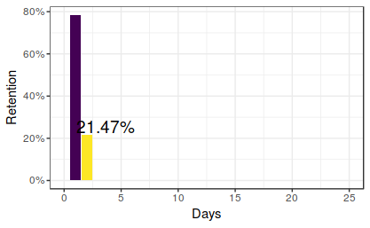

```r
library(scales)
ret <- as.data.frame(table(df$ret))
ret$Freq <- as.numeric(ret$Freq/sum(ret$Freq))
ret$Var1 <- as.numeric(ret$Var1)
ret$colour <- ifelse(ret$Var1 == 2 | ret$Var1 == 7 | ret$Var1 == 10, "yellow", "blue")
gg <- ggplot(ret,  aes(x=order(Var1), y=Freq, fill=colour)) +
    geom_bar(stat="identity") +
    scale_y_continuous(labels = scales::percent_format()) +
    scale_x_continuous(limits=c(0,25)) +
    scale_fill_viridis(discrete = TRUE) +
    geom_text(aes(label=ifelse(Var1 == 2 | Var1 == 7 | Var1 == 10, percent(round(Freq, digits= 4)), "")), vjust = -0.15, hjust = +0.18, size = 5, position = position_dodge(width = 0)) +
    theme_bw() +
    labs(x = "Days", y = "Retention") +
    theme(legend.position = "NONE")

gg
```

## Step 2

**Please explain if the results are the same using the two different ids and if not why not.**

I am not entirely confident if I correctly unerstood the question. But at this point we should notice that it makes no sense whatsoever to group the users using their `device_id` because we have data only from one day. This implies that we can not know anything about those users at any other day.

## Step 3

**Please explain how much of the variation in the 2nd day retention can be explained by whether or not the user completed the tutorial on the 1st day and whether it is a significant variable in understanding 2nd day retention. (You know if someone has complete the tutorial from the funnel steps in the user file. We are interested in the variable called funnel_1d and anyone with a funnel step higher than 2116 has completed the tutorial). You have to use a logistic regression.**

```r
df.tutorial <- raw.user[,c("user_id", "funnel_1d")]
df.tutorial$tut <- ifelse(df.tutorial$funnel_1d > 2116, 1, 0)
df.tutorial$tut[is.na(df.tutorial$tut)] <- 0
pass.tutorial <- df.tutorial[,c(1,3)]
pass.tutorial$user_id <- as.factor(pass.tutorial$user_id)
ret2f <- df %>%
    mutate(ret2 = ifelse(ret == 2, 1, 0)) %>%
    group_by(user_id,ret2 )
ret2f$user_id <- as.factor(ret2f$user_id)
ret2 <- ret2f[,c(1,3)] %>%
    group_by(user_id) %>%
    summarise(ret2=sum(ret2))
tut.ret <- merge(pass.tutorial, ret2)
tut.ret$tut <- as.factor(tut.ret$tut)
tut.ret$ret2 <- as.factor(tut.ret$ret2)
```

Now we have the data ready for testing and doing regressions.

The first question to be answered now is whether or not these two variables we are considering are correlated. Our variables are cathegorical. This means that they do not express a magnitude by a factor that labels a category. Two cathegorical variables can be correlated in the same sense as two numerical variables; but the statistical test performed for each case is quite different. To measure the dependence between cathegorical variables there is a widely used test, named *Chi-Squared Test*. Using this test, we can decide whether or not two cathegorical variables are correlated.

```r
library(MASS)
tb1 <- table(tut.ret$tut, tut.ret$ret2)
chisq.test(tb1)
```

```
    Pearson's Chi-squared test with Yates' continuity correction

data:  tb1
X-squared = 2168.5, df = 1, p-value < 2.2e-16
```

The result of this test is plainly clear. This result states that these variables are not independent. Thus, we conclude that there is a relationship between having finished the tutorial and the 2nd day retention.

Now, we can check further the relationship between these variables using a *Logistic Regression*. The point of using this regression is that is common to predict categorical outcomes using categorical variables. We can perform a Logistic Regression trying to predict whether or not some player have been retented the 2nd day since its regristration and determine if the `tutorial` variable (which is categorical) is useful for this prediction.

```r
model <- glm(tut.ret$ret2 ~ tut.ret$tut, family = binomial)
summary(model)
```

```
Call:
glm(formula = tut.ret$ret2 ~ tut.ret$tut, family = binomial)

Deviance Residuals:
    Min       1Q   Median       3Q      Max
-0.9204  -0.9204  -0.3465  -0.3465   2.3844

Coefficients:
             Estimate Std. Error z value Pr(>|z|)
(Intercept)  -2.78256    0.04733  -58.79   <2e-16 ***
tut.ret$tut1  2.14282    0.05187   41.31   <2e-16 ***
---
Signif. codes:  0 ‘***’ 0.001 ‘**’ 0.01 ‘*’ 0.05 ‘.’ 0.1 ‘ ’ 1

(Dispersion parameter for binomial family taken to be 1)

    Null deviance: 18715  on 17962  degrees of freedom
Residual deviance: 16284  on 17961  degrees of freedom
AIC: 16288

Number of Fisher Scoring iterations: 5
```

Considering the pvalue obtained, the variable that indicates whether or not a player was completed the tutorial is relevant to determine the 2nd day retention of that player.

Now that we know that the variable *is* relevant, we could ask *how much* relevant it is. Or, in other words, how much variation of the prediction on the 2nd day retention is caused by this variable. In Logistic Regression, technically we can not talk about any measure of *How much variation can be explained by this variable*. If we were talking about linear regression we could simply compute the $R^2$ and interpret its result as the percentage of the variation that could be explained with the variable; but there is no such thing in Logistic Regression. Notwithstanding, there are some so-called pseudo-$R^2$ as `Cos & Snell` and `Nagelkerke`.

Now we are going to apply the latter, since it is an adjustment of the former.

```r
library(rms)
x <- as.numeric(tut.ret$tut)
y <- as.numeric(tut.ret$ret2)
model2 <- lrm(y ~ x)
print(model2)
```

```
Logistic Regression Model

 lrm(formula = y ~ x)

                       Model Likelihood     Discrimination    Rank Discrim.
                          Ratio Test           Indexes           Indexes
 Obs         17963    LR chi2    2431.10    R2       0.196    C       0.710
  1          14095    d.f.             1    g        1.062    Dxy     0.421
  2           3868    Pr(> chi2) <0.0001    gr       2.892    gamma   0.790
 max |deriv| 3e-08                          gp       0.142    tau-a   0.142
                                            Brier    0.149

           Coef    S.E.   Wald Z Pr(>|Z|)
 Intercept -4.9254 0.0970 -50.77 <0.0001
 x          2.1428 0.0519  41.31 <0.0001
```

[1]: [*D.W. Hosmer and S. Lemeshow* (2000). Applied Logistic Regression](https://www.amazon.com/Applied-Logistic-Regression-Probability-Statistics/dp/0471356328)

## Step 4:

**Please identify two other significant variables that we should look at to improve day 2 retention and quantify how mmuch of the variation in retention can be explained by these variables.**

```r
x <- raw.user[,c("user_id", "register_platform", "register_ip_country")]
x$user_id <- as.factor(x$user_id)
x$register_platform <- as.factor(x$register_platform)
x$register_ip_country <- as.factor(x$register_ip_country)
df <- merge(tut.ret, x, by = "user_id", all.x = TRUE)
# Clean duplicates
df <- df[!duplicated(df),]
# Perform Logistic Regression
rm(df.tutorial, g, model, model2, pass.tutorial, reg, ret, ret2, ret2f, tut.ret, x, a, tb1, y ,z)
```

[output not shown]

```r
model <- glm(df$ret2 ~ df$register_platform + df$register_ip_country + df$tut, family = binomial)
summary(model)
```

```
Call:
glm(formula = df$ret2 ~ df$register_platform + df$register_ip_country +
    df$tut, family = binomial)

Deviance Residuals:
    Min       1Q   Median       3Q      Max
-1.5293  -0.8755  -0.3869  -0.2330   2.7352

Coefficients:
                           Estimate Std. Error z value Pr(>|z|)
(Intercept)               -15.99886  309.97814  -0.052 0.958837
df$register_platformios     2.14005    0.55355   3.866 0.000111 ***
df$register_ip_countryAE   13.84667  309.97857   0.045 0.964371
df$register_ip_countryAF   11.43456  309.97987   0.037 0.970574
df$register_ip_countryAG   14.53708  309.97906   0.047 0.962595
df$register_ip_countryAL   13.87405  309.97823   0.045 0.964300
df$register_ip_countryAM   -0.41799  739.80827  -0.001 0.999549
df$register_ip_countryAR   13.25995  309.97868   0.043 0.965879
df$register_ip_countryAT   14.48836  309.98120   0.047 0.962721
df$register_ip_countryAU   13.62164  309.97875   0.044 0.964949
df$register_ip_countryAZ    0.43279  631.41418   0.001 0.999453
df$register_ip_countryBB   14.04729  309.97825   0.045 0.963855
df$register_ip_countryBD   13.67309  309.97890   0.044 0.964817
df$register_ip_countryBE   14.13897  309.97892   0.046 0.963619
df$register_ip_countryBG   13.00400  309.97868   0.042 0.966538
df$register_ip_countryBH    0.43279  895.62665   0.000 0.999614
df$register_ip_countryBJ   15.99886  309.98136   0.052 0.958838
df$register_ip_countryBM    0.43279 1488.04181   0.000 0.999768
df$register_ip_countryBN   13.71019  309.97822   0.044 0.964721
df$register_ip_countryBO    0.43279  790.96899   0.001 0.999563
df$register_ip_countryBR   12.67381  309.97836   0.041 0.967387
df$register_ip_countryBS    0.43279 1074.79181   0.000 0.999679
df$register_ip_countryBT    0.43279 1074.79181   0.000 0.999679
df$register_ip_countryBY   13.44329  309.97872   0.043 0.965408
df$register_ip_countryBZ   29.48655 1488.04181   0.020 0.984190
df$register_ip_countryCA   13.51701  309.97837   0.044 0.965218
df$register_ip_countryCD   14.20753  309.98077   0.046 0.963443
df$register_ip_countryCG    0.43279 1488.04181   0.000 0.999768
df$register_ip_countryCL   -0.59856  627.21580  -0.001 0.999239
df$register_ip_countryCM   -1.64558 1488.04181  -0.001 0.999118
```

[output cut: 121 more lines]

```
df$register_ip_countryVE   12.72235  309.98020   0.041 0.967262
df$register_ip_countryVN   12.56580  309.97825   0.041 0.967664
df$register_ip_countryYE   13.36899  309.98039   0.043 0.965599
df$register_ip_countryZA   13.95983  309.97871   0.045 0.964080
df$tut1                     2.07838    0.05361  38.769  < 2e-16 ***
---
Signif. codes:  0 ‘***’ 0.001 ‘**’ 0.01 ‘*’ 0.05 ‘.’ 0.1 ‘ ’ 1

(Dispersion parameter for binomial family taken to be 1)

    Null deviance: 18681  on 17946  degrees of freedom
Residual deviance: 15890  on 17791  degrees of freedom
AIC: 16202

Number of Fisher Scoring iterations: 14
```

We just keep those variables that are useful and move on.

```r
imp.var <- df[,-c("register_ip_country")]
```

```r
model <- glm(df$ret2 ~ df$register_platform + df$tut, family = binomial)
summary(model)
```

```
Call:
glm(formula = df$ret2 ~ df$register_platform + df$tut, family = binomial)

Deviance Residuals:
    Min       1Q   Median       3Q      Max
-1.4278  -0.9190  -0.3467  -0.3467   2.3840

Coefficients:
                        Estimate Std. Error z value Pr(>|z|)
(Intercept)             -2.78174    0.04729 -58.822   <2e-16 ***
df$register_platformios  1.21522    0.52963   2.294   0.0218 *
df$tut1                  2.13826    0.05184  41.247   <2e-16 ***
---
Signif. codes:  0 ‘***’ 0.001 ‘**’ 0.01 ‘*’ 0.05 ‘.’ 0.1 ‘ ’ 1

(Dispersion parameter for binomial family taken to be 1)

    Null deviance: 18681  on 17946  degrees of freedom
Residual deviance: 16254  on 17944  degrees of freedom
AIC: 16260

Number of Fisher Scoring iterations: 5
```

Whereas the `tutorial` variable relevance is out of doubt, this variable concerning the platform in which the game has been installed is relevant just by the standard metrics (pvalue below $0.05$).

Let’s finde some other useful variables.

```r
x <- raw.user[,c("user_id", "date_register")]
x$user_id <- as.factor(x$user_id)
x$date_register <- date(x$date_register)
x$month_register <- as.factor(month(x$date_register))
x$year_register <- as.factor(year(x$date_register))
x$wday_register <- as.factor(weekdays(x$date_register))
df <- merge(imp.var, x)
# Clean duplicates and NA
df <- df[!duplicated(df),]
df <- na.omit(df)
model <- glm(df$ret2 ~ df$tut + df$register_platform + df$month_register + df$year_register + df$wday_register, family=binomial)
summary(model)
```

```
Call:
glm(formula = df$ret2 ~ df$tut + df$register_platform + df$month_register +
    df$year_register + df$wday_register, family = binomial)

Deviance Residuals:
    Min       1Q   Median       3Q      Max
-1.4989  -0.8615  -0.3494  -0.3188   3.4657

Coefficients: (1 not defined because of singularities)
                           Estimate Std. Error z value Pr(>|z|)
(Intercept)               -16.09727  438.51811  -0.037 0.970718
df$tut1                     2.13347    0.05232  40.779  < 2e-16 ***
df$register_platformios     1.36210    0.53421   2.550 0.010780 *
df$month_register2         -1.89424  857.39336  -0.002 0.998237
df$month_register3         13.33169  438.51811   0.030 0.975747
df$month_register4         13.38732  438.51810   0.031 0.975646
df$month_register5         13.52230  438.51810   0.031 0.975400
df$month_register6         13.79397  438.51812   0.031 0.974906
df$month_register11        10.31775  438.51926   0.024 0.981229
df$month_register12        12.86036  438.51831   0.029 0.976604
df$year_register2015             NA         NA      NA       NA
df$wday_registerMonday     -0.29402    0.07486  -3.928 8.58e-05 ***
df$wday_registerSaturday   -0.06736    0.06823  -0.987 0.323502
df$wday_registerSunday      0.03446    0.07294   0.472 0.636635
df$wday_registerThursday   -0.10327    0.07287  -1.417 0.156396
df$wday_registerTuesday    -0.24395    0.06570  -3.713 0.000205 ***
df$wday_registerWednesday  -0.22367    0.06497  -3.443 0.000576 ***
---
Signif. codes:  0 ‘***’ 0.001 ‘**’ 0.01 ‘*’ 0.05 ‘.’ 0.1 ‘ ’ 1

(Dispersion parameter for binomial family taken to be 1)

    Null deviance: 18645  on 17924  degrees of freedom
Residual deviance: 16118  on 17909  degrees of freedom
AIC: 16150

Number of Fisher Scoring iterations: 14
```

Turns out that the `month` and the `year` in which a user has been registrated is of no importance in order to predict the 2nd day retention. What it is interesting is the great importance of the day of the week in which the registration was maded. Let’s isolate a bit the non-relevant variables and see with more detail what happens to this `weekday` variable.

```r
df <- df[,-c("month_register", "year_register")]
```

```r
model <- glm(df$ret2 ~ df$tut + df$register_platform + df$wday_register, family=binomial)
summary(model)
```

```
Call:
glm(formula = df$ret2 ~ df$tut + df$register_platform + df$wday_register,
    family = binomial)

Deviance Residuals:
    Min       1Q   Median       3Q      Max
-1.5064  -0.8685  -0.3603  -0.3257   2.4343

Coefficients:
                          Estimate Std. Error z value Pr(>|z|)
(Intercept)               -2.61803    0.05984 -43.747  < 2e-16 ***
df$tut1                    2.11642    0.05208  40.638  < 2e-16 ***
df$register_platformios    1.24834    0.52818   2.363   0.0181 *
df$wday_registerMonday    -0.29189    0.07465  -3.910 9.22e-05 ***
df$wday_registerSaturday  -0.08396    0.06737  -1.246   0.2127
df$wday_registerSunday     0.02846    0.07206   0.395   0.6929
df$wday_registerThursday  -0.17840    0.06959  -2.564   0.0104 *
df$wday_registerTuesday   -0.27896    0.06397  -4.360 1.30e-05 ***
df$wday_registerWednesday -0.27913    0.06167  -4.526 6.01e-06 ***
---
Signif. codes:  0 ‘***’ 0.001 ‘**’ 0.01 ‘*’ 0.05 ‘.’ 0.1 ‘ ’ 1

(Dispersion parameter for binomial family taken to be 1)

    Null deviance: 18645  on 17924  degrees of freedom
Residual deviance: 16177  on 17916  degrees of freedom
AIC: 16195

Number of Fisher Scoring iterations: 5
```

Interesting enough, not all days are equally important. But some of them are undoubtedly relevant.

In order to measure the pseudeo-R squared as we did before, we need to create dummy variables out of our actual variables.

```r
library(dummies)
dum.df <- df[,c("user_id", "tut", "ret2")]
dum.df <- cbind(dum.df, dummy(df$register_platform, sep="_"))
dum.df <- cbind(dum.df, dummy(df$wday_register, sep="_"))
```

And simply perform the logistic regression again

```r
test <- dum.df[,-c("user_id")]
test$tut <- as.numeric(as.character(test$tut))
colnames(test) <- c("tut", "ret2", "android", "ios", "friday", "monday", "saturday", "sunday", "thursday", "tuesday", "wednesday")
modeltut <- lrm(formula = test$ret2 ~ test$tut)
modelwed <- lrm(formula = test$ret2 ~ test$wednesday)
modelmon <- lrm(formula = test$ret2 ~ test$monday)
modeltue <- lrm(formula = test$ret2 ~ test$tuesday)
modeltut$stats[10]
```

```
       R2
0.1952651
```

```r
modelwed$stats[10]
```

```
         R2
0.002457038
```

```r
modelmon$stats[10]
```

```
         R2
0.001381453
```

```r
modeltue$stats[10]
```

```
         R2
0.001280012
```

Despite that the statistical tests stated that these are relevant variables, we can notice how small their pseudo-$R^2$ are, compared to our first variable.